# Настройка SMTP-сервера Postfix

Лабораторная работа №8

Элсаиед Адел

Российский университет дружбы народов, Москва, Россия

4 января 2026

# Цель и задачи работы

## Цель лабораторной работы

Приобретение практических навыков установки, настройки и проверки работы SMTP-сервера Postfix в виртуальной среде.

# Выполнение работы

## Установка почтовых пакетов

На виртуальной машине server выполнена установка пакетов Postfix и s-nail, необходимых для организации и тестирования почтовой службы.

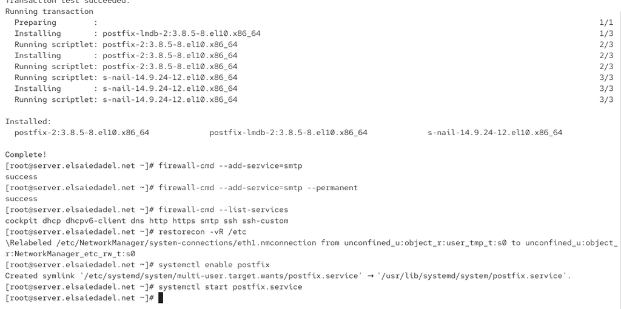

Установка Postfix

## SELinux и запуск службы

Выполнено восстановление контекстов безопасности SELinux.  
Служба Postfix добавлена в автозагрузку и успешно запущена.

[figure not shown]

Запуск Postfix

# Настройка Postfix

## Просмотр текущих параметров

Произведён анализ текущей конфигурации Postfix, включая параметры домена и источника исходящей почты.

[figure not shown]

Просмотр параметров

## Изменение параметров

В конфигурации Postfix выполнены изменения: - настройка доменного имени; - приведение параметра myorigin к mydomain; - отключение IPv6; - настройка сетевых интерфейсов.

[figure not shown]

Изменение конфигурации

## Отправка тестового письма

С сервера отправлено тестовое письмо локальному пользователю.  
Сообщение успешно принято и доставлено.

[figure not shown]

Отправка письма

## Анализ журналов

По журналу maillog подтверждена успешная доставка письма в локальный почтовый ящик.

[figure not shown]

Журнал Postfix

## Установка и запуск Postfix

На виртуальной машине client выполнена установка Postfix и s-nail, отключён IPv6, служба запущена.

[figure not shown]

Postfix на клиенте

## Ошибка доставки доменной почты

Письмо на доменный адрес помещено в очередь Postfix. В логах зафиксированы ошибки маршрутизации.

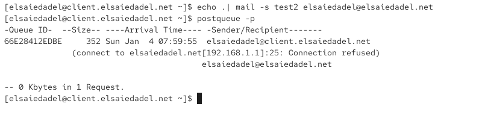

Очередь Postfix

## Настройка DNS

Добавлены: - MX-запись для домена; - A-запись почтового сервера; - PTR-записи в обратной зоне.

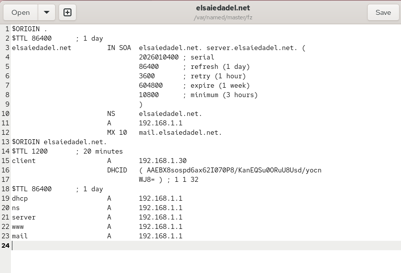

Прямая DNS-зона

## Настройка DNS

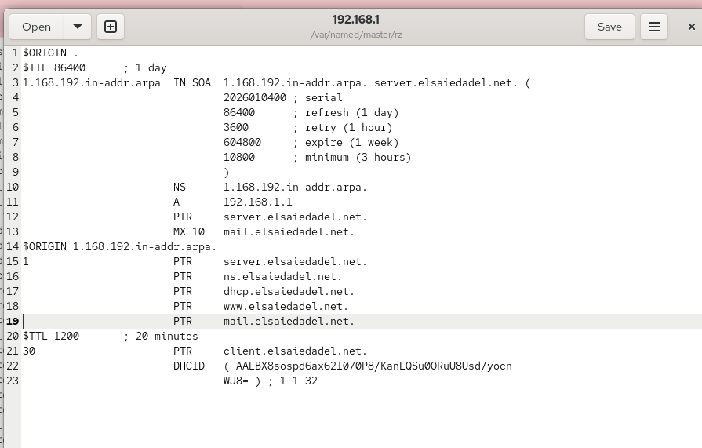

Обратная DNS-зона

## Применение изменений

Выполнена перезагрузка Postfix и DNS, восстановлены SELinux-контексты.  
Очередь сообщений успешно обработана.

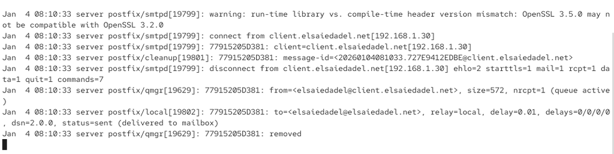

Успешная доставка

## Provisioning-скрипты

Созданы скрипты mail.sh для server и client, автоматизирующие: - установку пакетов; - настройку Postfix; - запуск служб.

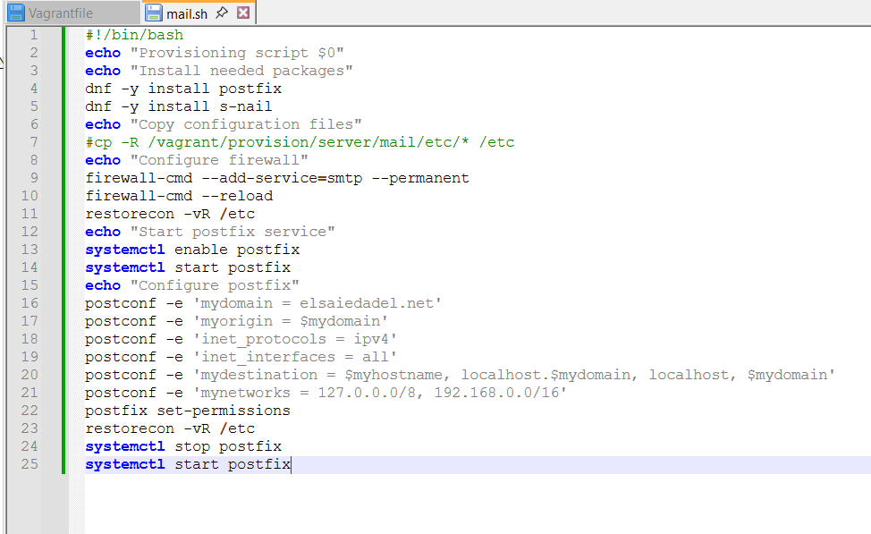

Скрипт server

## Provisioning-скрипты

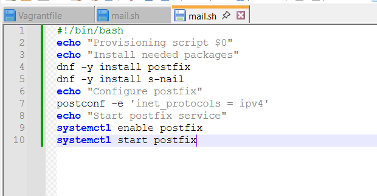

Скрипт client

# Выводы

## Вывод

В ходе лабораторной работы выполнена установка и настройка SMTP-сервера Postfix. Обеспечена локальная и доменная доставка почты, настроены DNS-записи и сетевые параметры. Реализована автоматизация конфигурации почтовой подсистемы, что повышает воспроизводимость и упрощает развёртывание почтового сервера в виртуальной среде.